# HW1

## April 3, 2023

## Homework 1

```python
import numpy as np
import matplotlib.pyplot as plt
from scipy.integrate import quad
plt.style.use('ggplot')
```

## Problem 1(a)

$x(t) = \sin(3\pi t + 1) + 2\cos(4t)$

### Solution:

The signal $x(t)$ is NOT periodic.

```python
# Problem (a)
omega1 = 3 * np.pi
omega2 = 4
T1 = 2 * np.pi / np.abs(omega1)
T2 = 2 * np.pi / np.abs(omega2)

print(f"T1: {T1}, T2: {T2}")
# No common multiple, so signal is not periodic
```

```
T1: 0.6666666666666666, T2: 1.5707963267948966
```

## Problem 1(b)

$x(t) = \sin(0.1\pi t) + e^{j\pi t}$

### Solution:

The signal $x(t)$ is periodic with a fundamental period of $T = 20$.

```python
# Problem (b)
omega1 = 0.1 * np.pi
omega2 = np.pi
T1 = 2 * np.pi / np.abs(omega1)
T2 = 2 * np.pi / np.abs(omega2)

print(f"T1: {T1}, T2: {T2}")
# LCM of T1 and T2 is 20, so signal is periodic with fundamental period T = 20
```

```
T1: 20.0, T2: 2.0
```

## Problem 1(c)

$x(t) = \cos(\pi t) + e^{-t}\sin(\pi t)$

### Solution:

The signal $x(t)$ is NOT periodic.

```python
# Problem (c)
# First component is periodic with T1 = 2
# Second component is not periodic because of the e^(-t) term, so the overall signal is not periodic
```

## Problem 1(d)

$x(t) = \sin^2(\pi t)$

### Solution:

The signal $x(t)$ is periodic with a fundamental period of $T = 1$.

```python
# Problem (d)
omega = np.pi
T = np.pi / np.abs(omega)

print(f"T: {T}")
# Signal is periodic with fundamental period T = 1
```

```
T: 1.0
```

## Problem 2(a)

$x[n] = 2\sin(2n + \pi/4)$

### Solution:

The signal $x[n]$ is NOT periodic.

```python
# Problem (a)
omega = 2
# Signal is not periodic since omega/2π is not rational
```

## Problem 2(b)

$x[n] = 2\cos(5/4\pi n) + \cos(\pi n)$

### Solution:

The signal $x[n]$ is periodic with a fundamental period of $N = 8$.

```python
# Problem (b)
omega1 = 5 / 4 * np.pi
omega2 = np.pi
N1 = 8  # Smallest integer multiple of 2π/omega1
N2 = 2  # Smallest integer multiple of 2π/omega2
N = np.lcm(N1, N2)

print(f"N: {N}")  # Signal is periodic with fundamental period N = 8
```

```
N: 8
```

## Problem 2(c)

$x[n] = \cos(\pi/2 n) \cdot \cos(\pi/4 n)$

### Solution:

The signal $x[n]$ is periodic with a fundamental period of $N = 8$.

```python
# Problem (c)
omega1 = np.pi / 2
omega2 = np.pi / 4
N1 = 4  # Smallest integer multiple of 2π/omega1
N2 = 8  # Smallest integer multiple of 2π/omega2
N = np.lcm(N1, N2)

print(f"N: {N}")  # Signal is periodic with fundamental period N = 8
```

```
N: 8
```

## Problem 2(d)

$x[n] = \cos(\pi/8 n^2)$

### Solution:

The signal $x[n]$ is NOT periodic.

```python
# Problem (d)
# Signal is not periodic since it has a quadratic term in the argument of the cosine function
```

## Problem 3(a)

$x(t) = e^{-3t}$

### Solution:

The signal $x(t)$ is bounded. The minimal finite upper bound is $1$.

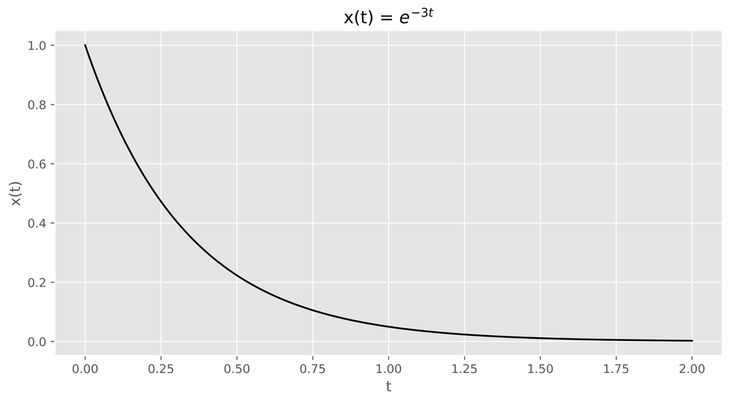

```python
# Problem (a)
plt.figure(figsize=(10, 5), dpi = 800)
t = np.linspace(0, 2, 1000)
x_a = np.exp(-3 * t)
plt.plot(t, x_a, color = "black")
plt.title("x(t) = $e^{-3t}$")
plt.xlabel("t")
plt.ylabel("x(t)")
plt.show()
# Signal is bounded, minimal finite upper bound is 1
```

## Problem 3(b)

$x(t) = t^2u(t-3)u(t+2)$

### Solution:

The signal $x(t)$ is not bounded.

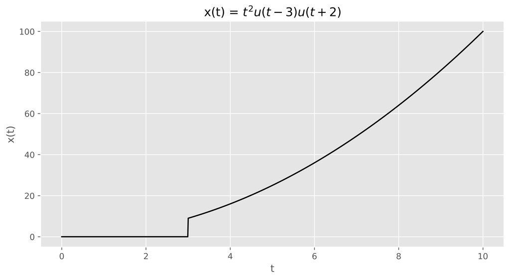

```python
# Problem (b)
plt.figure(figsize=(10, 5), dpi = 800)
t = np.linspace(0, 10, 1000)
x_b = t ** 2 * np.heaviside(t - 3, 1) * np.heaviside(t + 2, 1)
plt.plot(t, x_b, color = "black")
plt.title("x(t) = $t^2u(t-3)u(t+2)$")
plt.xlabel("t")
plt.ylabel("x(t)")
plt.show()
# The signal is not bounded
```

## Problem 3(c)

$x[n] = 3^{-n}u[n] + 0.5^{n}u[-n]$

### Solution:

The signal $x[n]$ is bounded. The minimal finite upper bound is $2$.

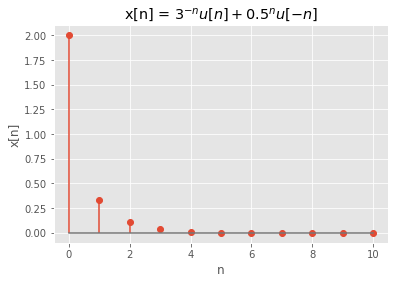

```python
# Problem (c)
n = np.arange(0, 11)
x_c = (1 / np.power(3, n)) * np.heaviside(n, 1) + (1 / np.power(0.5, -n)) * np.heaviside(-n, 1)
plt.stem(n, x_c)
plt.title("x[n] = $3^{-n}u[n] + 0.5^{n}u[-n]$")
plt.xlabel("n")
plt.ylabel("x[n]")
plt.show()
# Signal is bounded, minimal finite upper bound is 2
```

## Problem 4(a)

$x(t) = 3u(t) + e^t r(-t)$

## Problem (a)

$x(t) = 3u(t) + e^t r(-t)$

### Solution:

To determine if the signal is an energy signal or a power signal, we need to compute the energy and power.

Energy: $E = \int_{-\infty}^{\infty} |x(t)|^2 dt$

Since $x(t)$ is defined as the sum of two signals, we can split the integral into two parts:

$E = \int_{-\infty}^{\infty} |3u(t)|^2 dt + \int_{-\infty}^{\infty} |e^t r(-t)|^2 dt$

The first integral corresponds to $|3u(t)|^2$:

$E_1 = \int_{0}^{\infty} (3)^2 dt = 9\int_{0}^{\infty} dt$

The second integral corresponds to $|e^t r(-t)|^2$:

$E_2 = \int_{-\infty}^{0} (e^t)^2 dt = \int_{-\infty}^{0} e^{2t} dt$

Now, we can compute the integrals:

$E_1 = 9\int_{0}^{\infty} dt = 9t\Big|_{0}^{\infty} = \infty$

$E_2 = \int_{-\infty}^{0} e^{2t} dt = \frac{1}{2}e^{2t}\Big|_{-\infty}^{0} = \frac{1}{2}(1 - 0) = \frac{1}{2}$

Since $E_1$ is infinite, the total energy $E = E_1 + E_2$ is also infinite, so the signal is NOT an energy signal.

To check if the signal is a power signal, we need to compute the power:

Power: $P = \lim_{T\to\infty}\frac{1}{2T}\int_{-T}^{T} |x(t)|^2 dt$

Since the energy is infinite, the power will also be infinite. Thus, the signal is NOT a power signal.

The signal is neither an energy signal nor a power signal.

## Problem (b)

$x[n] = 3^{-n}u[n] + (0.5)^n u[-n]$

### Solution:

First, we compute the energy of the signal.

$$ E = \sum_{n=-\infty}^{\infty} |x[n]|^2 = \sum_{n=-\infty}^{-1} |(0.5)^n|^2 + \sum_{n=0}^{\infty} |3^{-n}|^2 $$

Since the two terms in the signal are multiplied by unit step functions, they do not overlap, and we can compute the energy of each term separately.

$$ E = \sum_{n=-\infty}^{-1} (0.5)^{2n} + \sum_{n=0}^{\infty} (3^{-n})^2 = \sum_{n=-\infty}^{-1} (0.25)^n + \sum_{n=0}^{\infty} 3^{-2n} $$

Both terms are geometric series with common ratios less than 1, so they converge. The energy of the first term is:

$$ E_1 = \frac{(0.25)^{-\infty} - (0.25)^{-1}}{1 - 0.25} = \frac{1}{0.75} = 1.333\ldots $$

The energy of the second term is:

$$ E_2 = \frac{1 - 3^{-2\infty}}{1 - 3^{-2}} = \frac{1}{1 - 1/9} = \frac{1}{8/9} = 1.125 $$

The total energy is:

$$ E = E_1 + E_2 = 1.333\ldots + 1.125 = 2.458\ldots $$

The energy is finite, and the power is zero since the signal decays as n increases or decreases. Thus, the signal $x[n]$ is an energy signal with energy $E \approx 2.458$ and power $P = 0$.

## Problem 5(a)

$x(t) = 2(2t - 1) + u(-2t) + r(t+1)$ for $t \in [-7, 7]$

### Solution:

We will break down the signal into its constituent functions and then combine them to visualize the complete signal.

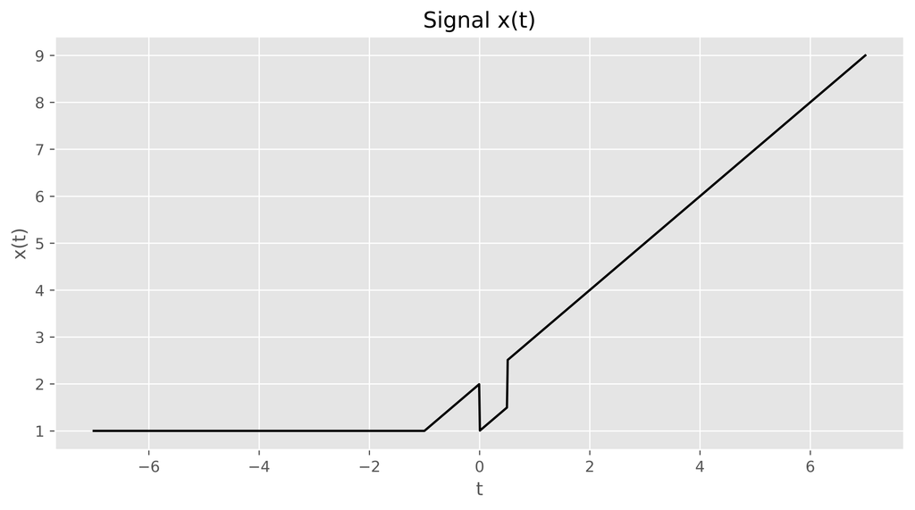

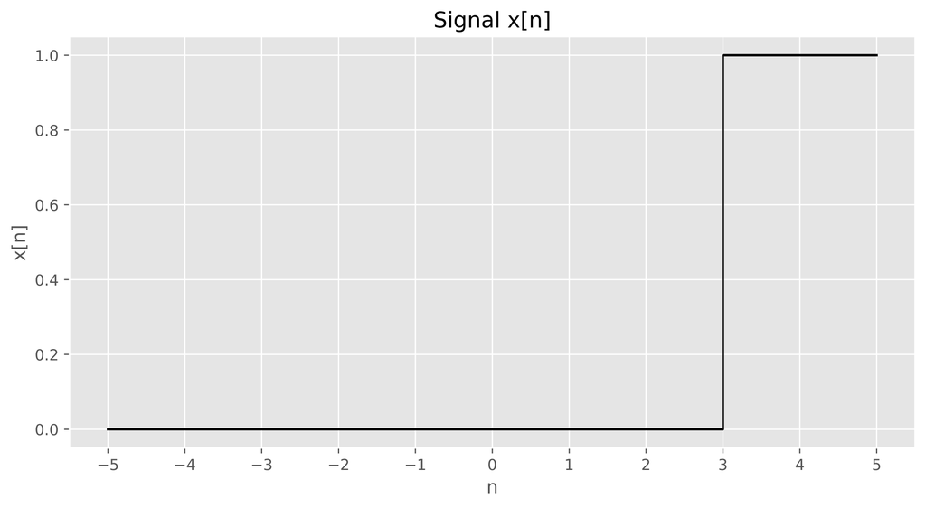

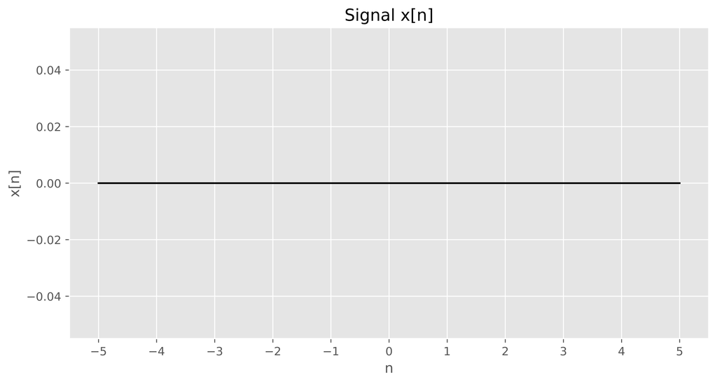

```python
# Problem (a)

t = np.linspace(-7, 7, 1000)
x = np.piecewise(t, [
    t < -1,
    (-1 <= t) & (t < 0),
    (0 <= t) & (t < 0.5),
    0.5 <= t
], [
    1,
    lambda t: 1 + (t + 1),
    lambda t: t + 1,
    lambda t: t + 2
])
plt.figure(figsize=(10, 5), dpi=800)
plt.plot(t, x, color='black')
plt.xlabel('t')
plt.ylabel('x(t)')
plt.title('Signal x(t)')
plt.grid(True)
plt.show()

plt.figure(figsize=(10, 5), dpi=800)
n = np.arange(-5, 6)
x = np.piecewise(n, [n < 4, n >= 4], [0, 1])

plt.step(n, x, color = "black")
plt.xlabel('n')
plt.ylabel('x[n]')
plt.title('Signal x[n]')
plt.grid(True)
plt.xticks(np.arange(-5, 6, 1))
plt.show()

plt.figure(figsize=(10, 5), dpi=800)
n = np.arange(-5, 6)
x = np.piecewise(n, [n < 5, (5 <= n) & (n <= 3), n > 3], [0, 1, 0])

plt.step(n, x, color = "black")
plt.xlabel('n')
plt.ylabel('x[n]')
plt.title('Signal x[n]')
plt.grid(True)
plt.xticks(np.arange(-5, 6, 1))
plt.show()
```

## Problem 6

### Solution:

We will first define the original signal $x^*(t)$ and then apply the transformation to obtain $y(t)$.

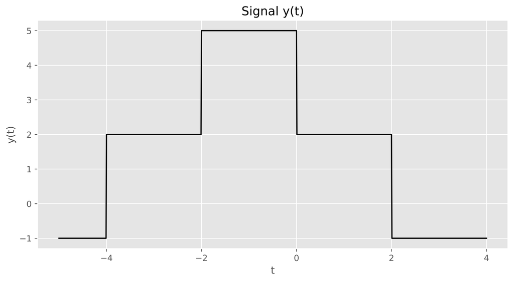

```python
def x_3(t):
    return np.piecewise(t, [
        t < -1,
        (-1 <= t) & (t < 0),
        (0 <= t) & (t <= 1),
        (1 < t) & (t <= 2),
        2 < t
    ], [
        0,
        1,
        2,
        1,
        0
    ])
plt.figure(figsize=(10, 5), dpi=800)
t = np.linspace(-5, 4, 1000)
y = -1 + 3 * x_3(t/2 + 1)

plt.plot(t, y, color = "black")
plt.xlabel('t')
plt.ylabel('y(t)')
plt.title('Signal y(t)')
plt.grid(True)
plt.show()
```